# Final Exam

Ziyue Wang

# Problem 1

### (a)

Define the number of blue fish in a size-100 simply random sample as $y \in \{0, \dots, 100\}$ and the number of green fish is $100-y$ which is completely determined by $y$. Let $y_1$ be the first batch and let $y_2$ be the second batch so $y=(y_1, y_2)$. Define $I$ to be the inclusion variable that means whether the $y_i$ is observed or not. In our case $I=(1, 0)$. Define the number of tagged fish in the second or later capture of 100 fish to be $z \in \{0, \dots, 100\}$. The complete data model given $(N_b, N_g)$ and thus given $N:=N_b+ N_g$ is

$$p(y, z, I, |N_b, N_g) = p(y|N_b, N_g) p(z|N_b, N_g) p(I),$$
where

$$\begin{equation*}
p(y|N_b, N_g) =
\begin{cases}
\prod_{i=1}^{2}\frac{{N_b\choose{y_i}}{N_g\choose{100-y_i}}}{N\choose{100}} & \text{if $y_i \leq N_b$ and $100-y_i \leq N_g$}\\
0 & \text{otherwise}
\end{cases}
\end{equation*}$$

and

$$\begin{equation*}
p(z|N_b, N_g) =
\begin{cases}
\frac{{100 \choose z}{N-100 \choose 100-z}}{N\choose 100} & \text{if $z \leq 100$ and $100-z \leq N-100$}\\
0 & \text{otherwise}
\end{cases}
\end{equation*}$$

For the missing mechanism, since knocking over the fish bucket is completely out of our control and is obviously not determined by the number of fish in the pond, we would assume that this knocking over is completely at random and that $p(I)$ is some unknown distribution on $\{1, 0\}^2$ that does not need to be estimated. Please note that only $y$ can be missing and we always have complete data for $z$.

For the model for observed data $y_{\text{obs}}$, since we assume that $p(I)$ does not depend on $y$ or $N_b$, $N_g$ we have

$$\begin{align*}
p(y_{\text{obs}}, z, I, |N_b, N_g) &= p(z|N_b, N_g) \int p(y_{\text{obs}}, y_{\text{mis}}|N_b, N_g) p(I) \, d y_{\text{mis}}\\
&= p(z|N_b, N_g) p(I) \int p(y_{\text{obs}}, y_{\text{mis}}|N_b, N_g) \, d y_{\text{mis}}\\
&= p(z|N_b, N_g) p(I) p(y_{\text{obs}}|N_b, N_g).
\end{align*}$$

So the missing of the second bucket fish does not harm the estimation of $(N_b, N_g)$.

### (b)

We will use an weakly informative prior for $(N_b, N_g)$ and assuming that $N_b$ is independent of $N_g$. It will depends on the observed data $y_{\text{obs}} := y_1$ and $z$ but it is still a valid prior not a conditional distribution.

We use Poisson distribution for the priors, however it is assigned to $N_b$ and $N_g$ with a mean shift such that it is consistent with what we observed in $y_1$ and $z$:

$$p(N_b) = \text{Poisson}(N_b-y_1-(200-z)\,|\, \lambda_b),$$
and

$$p(N_g) = \text{Poisson}(N_g-(100-y_1)\,|\, \lambda_g).$$

This prior guarantees that $(N_b, N_g)$ matches the reality and it is reasonable to use observed data to define prior. If you capture 100 fish and observe that $y_1$ of them are blue, then release the fish to the pond and capture 100 fish again and observe that $z$ of them are from the first batch, this immediately implies that the total number of fish in the pond is greater than $200-z$, total number of blue fish is greater than $y_1$ and total number of green fish is greater than $100-y_1$. To reflect these facts in the prior, we let $N_b$ always greater than $y_1+(200-z)$ and $N_g$ always greater than $(100-y_1)$. Please note that we give all the $z$ numbers to $N_b$, this is a relatively compromised way to enforce that $N_b + N_g \geq 200 -z$ but should not affect the estimation of $N_b$ and $N_g$ in the end.

After setting the deterministic lower bound we make the fluctuation follows a Poisson distribution with parameter $\lambda_b$ and $\lambda_g$ respectively.

### (c)

The joint posterior given $y_{\text{obs}}:=y_1$, $z$ and $I$ is
$$\begin{align*}
p(N_b, N_g | y_{\text{obs}}, z, I ) &\propto p(N_b) p(N_g) p(y_{\text{obs}}, z, I, |N_b, N_g)\\
&= p(N_b) p(N_g) p(I) p(z|N_b, N_g) p(y_{\text{obs}}|N_b, N_g)\\
&\propto p(N_b) p(N_g) p(z|N_b, N_g) p(y_{\text{obs}}|N_b, N_g) \qquad \text{Since $p(I)$ is constant for $N_b$ and $N_g$}\\
&= \frac{\lambda_b^{N_b-y_1-(200-z)} e^{-\lambda_b}}{(N_b-y_1-(200-z))!} \frac{\lambda_g^{N_b-(100-y_1)} e^{-\lambda_g}}{(N_b-(100-y_1))!} \frac{{100 \choose z}{N-100 \choose 100-z}}{N\choose 100} \frac{{N_b\choose{y_{\text{obs}}}}{N_g\choose{100-y_{\text{obs}}}}}{N\choose{100}}
\end{align*}$$
Please note that in above expression $y_{\text{obs}}:=y_1$ so we equivalently used both notation in the formula. If in the future more than $y_1$ is observed then for the prior needs to be redefined to use the information in the new observed data.

# Problem 2

We know that for $a > 0$
$$p(a) = p(\log a) \left|\frac{1}{a} \right| = \frac{p(\log a)}{a},$$
and $p(a) = 0$ otherwise. However for convenience we are going to sample from $\log a$ and $\log b$ and all the following calculation are on $\log a$ and $\log b$.

### (a) Log posterior and the derivatives

Denote the log posterior as $\ell$, the partial derivatives are

$$\frac{d \ell}{d \alpha} = \frac{d \ell}{d a}\times\frac{d a}{d \alpha} = \exp(\alpha) \left\{ -\frac{\log(a/5)}{a(\log2)^2} + \sum_{i=1}^{n} \left\{ \log(bx_i) - \psi(a) + log y_i \right\}\right\},$$
where we use the logrithme derivative of Gamma function $\psi(x)$ which has a built-in function in R, for the formula see https://en.wikipedia.org/wiki/Digamma_function and page 3 of http://scipp.ucsc.edu/~haber/archives/physics116A10/psifun_10.pdf.

$$\frac{d \ell}{d \beta} = \frac{d \ell}{d b}\times\frac{d b}{d \beta} = \exp(\beta) \left\{-\frac{\log(10b)}{b(\log 10)^2} - \frac{1}{b} + \sum_{i=1}^{n} \left\{ \frac{a}{b} - x_i y_i \right\}\right\}.$$
Now we are ready to use HMC.

### (b) Sample from the posterior

First we simulate a size-100 dataset including $x$ and $y$.

```r
set.seed(2021)

n <- 100

x <- exp(rnorm(n))
a <- 2
b <- .3

y <- rgamma(n, shape=a, rate=b*x)
```

Next we use HMC to sample from the posterior. Let’s define the gradient and the log posterior in R.

```r
grad <- function(a, b) {
  # Input variable a is alpha not the parameter a. Same for variable b.
  a <- exp(a); b <- exp(b)
  grad_a <- a*(-log(a/5)/a/(log(2))^2 - 1/a - n*digamma(a) + sum(log(b*x) + log(y)))
  grad_b <- b*(-log(10*b)/b/(log(10))^2 - 1/b + n*a/b - sum(x*y))

  c(grad_a, grad_b)
}


logp <- function(a, b) {
  # Input variable a is alpha not the parameter a. Same for variable b.
  a <- exp(a); b <- exp(b)
  -log(2*pi) - log(log(2)) - log(log(10)) - log(a) - log(b) -
    (log(a/5)^2)/(2*(log(2))^2) -
    (log(10*b)^2)/(2*(log(10))^2) -
    n*lgamma(a) +
    sum(a*log(b*x) + (a-1)*log(y) - b*x*y)
}
```

```r
grad(1, -2)
```

```
## [1] -296.5505  170.9224
```

```r
c((logp(1+1e-5, -2) - logp(1, -2))/1e-5, (logp(1, -2+1e-5) - logp(1, -2))/1e-5)
```

```
## [1] -296.5537  170.9219
```

Now we are sure that the gradient is correct and we are ready to implement HMC.

```r
hmc <- function(iter, init) {
  Theta <- matrix(0, nrow=iter+1, ncol=2)
  Theta[1, ] <- init

  M <- matrix(c(5, 0, 0, 5), 2, 2)
  eps <- .008
  L <- 10
  Accept <- rep(NA, iter)

  for (i in 1:iter) {
  # Leapfrog
  Theta0 <- Theta[i, ]
  phi <- rnorm(2, mean=0, sd=diag(M))
  phi0 <- phi
  phi <- phi + .5*eps*grad(Theta0[1], Theta0[2])
  Theta0 <- Theta0 + eps*t(phi)%*%solve(M)
  for (j in 1:(L-1)) {
    phi <- phi + eps*grad(Theta0[1], Theta0[2])
    Theta0 <- Theta0 + eps*t(phi)%*%solve(M)
  }
  phi <- phi + .5*eps*grad(Theta0[1], Theta0[2])

  #Accept-reject sampling
  log_r <- logp(Theta0[1], Theta0[2]) - logp(Theta[i, 1], Theta[i, 2]) +
    sum(dnorm(phi, sd=diag(M), log=T)) - sum(dnorm(phi0, sd=diag(M), log=T))
  Accept[i] <- (log(runif(1)) < log_r)
  Theta[i+1, ] <- ifelse(rep(Accept[i], 2),
                         Theta0,
                         Theta[i, ])
  }
  return(list(chain=Theta, accept=Accept))
}

cat(paste("Acceptance rate is" ,mean(hmc(1e4, c(0, 1))$accept)))
```

```
## Acceptance rate is 0.6312
```

We use $L=10$ and tune the $M$ and $\epsilon$ such that acceptance rate is roughly $2/3$. In this case $M = 5I_2$ and $\epsilon=0.008$. Next we check the convergence of our HMC program.

### (c) Convergence diagnostics

We run four chains with dispersed initial values and check the mixing status.

```r
chain1 <- hmc(1e4, c(0, -2))$chain
chain2 <- hmc(1e4, c(1, -2))$chain
chain3 <- hmc(1e4, c(-1, 2))$chain
chain4 <- hmc(1e4, c(-2, 2))$chain

chains_loga <- cbind(chain1[, 1], chain2[, 1], chain3[, 1], chain4[, 1])
chains_logb <- cbind(chain1[, 2], chain2[, 2], chain3[, 2], chain4[, 2])
```

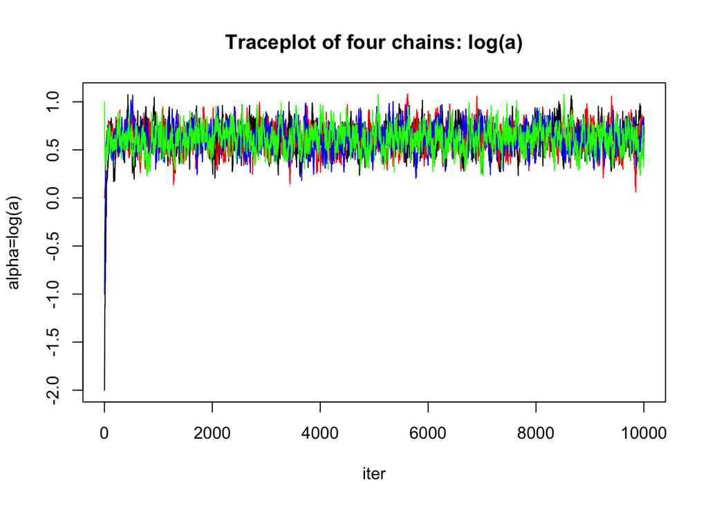

```r
plot(chains_loga[, 4], type="l",
     main="Traceplot of four chains: log(a)",
     xlab="iter",
     ylab="alpha=log(a)")
lines(chains_loga[, 1], col="red")
lines(chains_loga[, 3], col="blue")
lines(chains_loga[, 2], col="green")
```

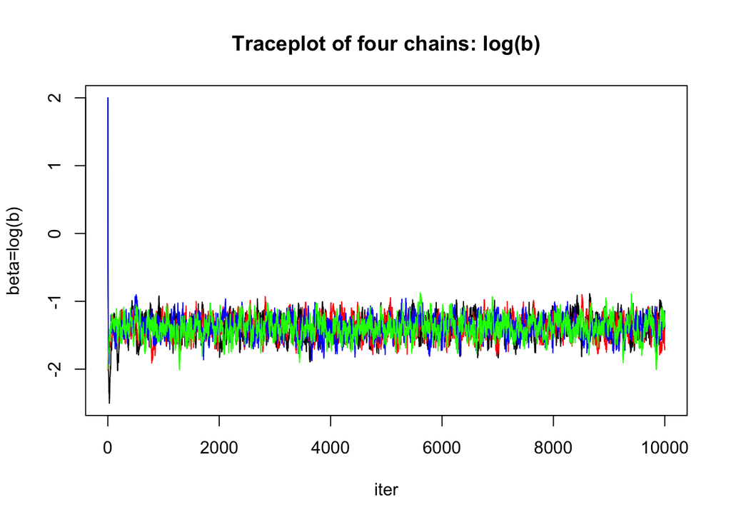

```r
plot(chains_logb[, 4], type="l",
     main="Traceplot of four chains: log(b)",
     xlab="iter",
     ylab="beta=log(b)")
lines(chains_logb[, 2], col="red")
lines(chains_logb[, 3], col="blue")
lines(chains_logb[, 1], col="green")
```

The traceplot looks good. Although the initial points are far from each other, the four chains eventually mixed together and becomes indistinguishable. From this we are confident that the chains approximately converged. However it does no harm to further check some statistics like the PSRF and effective sample size to numerically access the convergence.

```r
burn_in <- function(chain) {
  tail(chain, -.5*length(chain))
}

 my_diff <- function(t, x) {
    mean(diff(x, lag = t)^2, na.rm = TRUE)
 }

n_eff <- function(chains) {
  require(purrr)
  m <- ncol(chains)
  n <- nrow(chains)
  # Within-chain var
  W <- 1/m*sum(apply(chains, 2, var))

  means <- colMeans(chains)
  B <- n * var(means)

  V_plus <- (n-1)/n * W + 1/n * B
  Rhat <- sqrt(V_plus/W)

  V <- sapply(seq_len(nrow(chains) - 1), my_diff, x=chains[, 1]) + sapply(seq_len(nrow(chains) - 1), my_diff, x=chains[, 2]) + sapply(seq_len(nrow(chains) - 1), my_diff, x=chains[, 3]) + sapply(seq_len(nrow(chains) - 1), my_diff, x=chains[, 4])

  V <- V/m

  rho <- head_while(1 - V / (2*V_plus), ~. >0)

  n_hat_eff <- m*n / (1 + 2*sum(rho))
  return(list(n_hat_eff, Rhat))
}

chains_loga_burn <- apply(chains_loga, 2, burn_in)
res <- n_eff(chains_loga_burn)
cat(paste("log(a): The PSRF is", res[[2]]))
```

```
## log(a): The PSRF is 1.00172068524053
```

```r
cat(paste("\nThe estimated effective sample size is", res[[1]]))
```

```
##
## The estimated effective sample size is 616.64218064808
```

```r
chains_logb_burn <- apply(chains_logb, 2, burn_in)
res <- n_eff(chains_logb_burn)
cat(paste("\n\nlog(b): The PSRF is", res[[2]]))
```

```
##
##
## log(b): The PSRF is 1.00293577326083
```

```r
cat(paste("\nThe estimated effective sample size is", res[[1]]))
```

```
##
## The estimated effective sample size is 592.733958242492
```

Looks like the PSRF is close enough to $1$, and the estimated effective sample size is not as large as expected but is not bad. Combining these results with what we observed from the traceplot we conclude that the chains obtained from our HMC program are approximately converged.

### (d) Posterior inference

For the part (d) we will use the first chain in part (c) to do the posterior inference. Please note that our chains give sample of $\log(a)$ and $\log(b)$ so before we proceed we need to calculate their exponent.

Below is the summary of quantiles and mean of posterior samples.

```r
chain1_exp <- exp(chain1)
colnames(chain1_exp) <- c("a", "b")
summary(chain1_exp)
```

```
##        a               b
##  Min.   :1.000   Min.   :0.1338
##  1st Qu.:1.699   1st Qu.:0.2263
##  Median :1.856   Median :0.2490
##  Mean   :1.869   Mean   :0.2518
##  3rd Qu.:2.019   3rd Qu.:0.2748
##  Max.   :2.951   Max.   :0.4168
```

So the posterior mean of $a$ is $1.869$ and that of $b$ is $0.2518$. The mode is about the same. Both are close to the true value $(2, 0.3)$ but there are gaps. As the sample size of $x$ and $y$ increases the difference in posterior mean and true value will become smaller and smaller.

Let’s take a look at a $2$d Histogram. It looks better comparing to the scatterplot and contour plot.

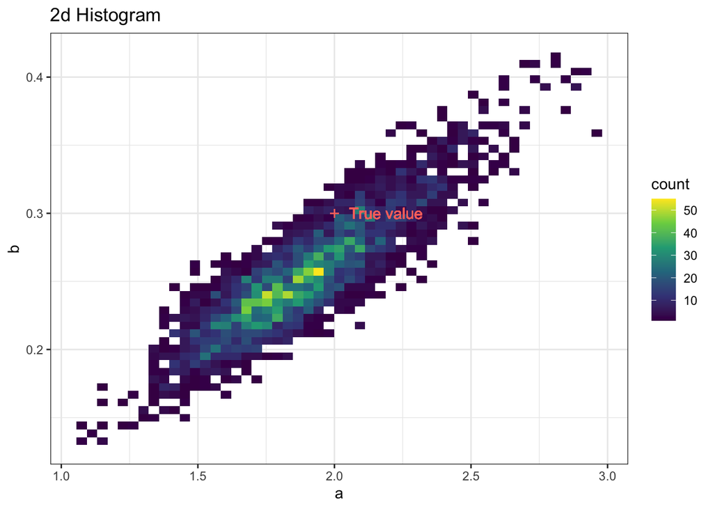

```r
burn_in <- function(chain) {
  tail(chain, -.5*dim(chain)[1])
}
library(ggplot2)
res <- burn_in(chain1_exp) # remove burn-in
plt_data <- as.data.frame(res)
colnames(plt_data) <- c('a', 'b')
ggplot(plt_data, aes(x=a, y=b) ) +
  geom_bin2d(bins = 50) +
  scale_fill_continuous(type = "viridis") +
  theme_bw() + ggtitle('2d Histogram') +
  geom_point(aes(x=2, y=.3, col='red'), shape=3) +
  geom_text(aes(x=2, y=.3, label="True value", col="red"), hjust=-.2) +
  guides(color = FALSE)
```

#### Scatterplot and contour plot

It is not reasonable to do a 5000 size scatterplot so I just randomly picked 500 points from the chain to draw the scatterplot. The coutour plot is using the entire chain.

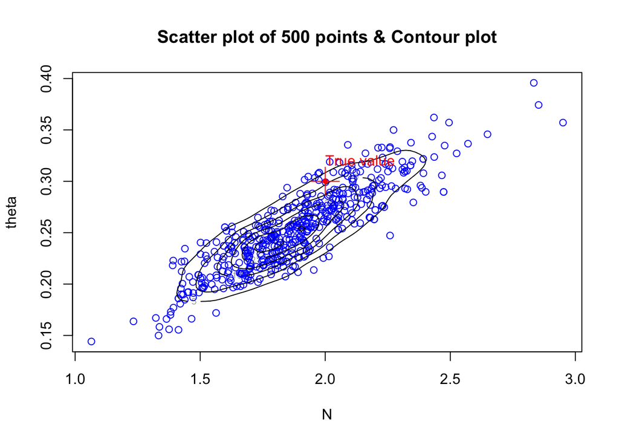

```r
library(MASS)
ind <- sample(nrow(res), 500)
plot(res[ind, 1], res[ind, 2], col='blue',
     xlab='N', ylab='theta', main='Scatter plot of 500 points & Contour plot')
contour(kde2d(res[, 1], res[, 2], n=100), add=TRUE)
points(x=2, y=0.3, pch=3, col="red", cex=3)
points(x=2, y=0.3, pch=20, col="red")
text(x=2, y=0.3, "True value", col="red", adj=c(0, -1.5))
```

From the plot it is again confirmed that the posterior mode is close to the true value, but there is an error which is reasonable since we only have 100 $y$ data points.